# ggsdc - seasonal decomposition on the fly

### Make rolling averages easily with `stat_rollapplyr()`

`stat_rollapplyr()` makes it easy to add a rolling function to your data, defaulting to the mean:

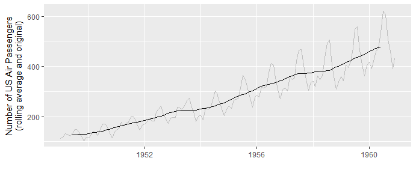

```r
ggplot(ap_df, aes(x = x, y = y)) +
   geom_line(colour = "grey75") +
   stat_rollapplyr(width = 12, align = "center") +
   labs(x = "", y = "Number of US Air Passengers\n(rolling average and original)")
```

It’s not very likely you’ll want anything but a line for a graphic like this, but in case you do, you can over-write the default geom. And of course all the usual `ggplot2` polishing facilities are available:

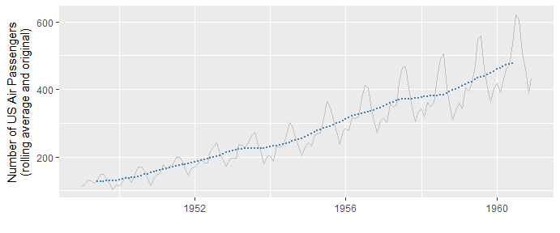

```r
ggplot(ap_df, aes(x = x, y = y)) +
   geom_line(colour = "grey75") +
   stat_rollapplyr(width = 12, align = "center", geom = "point",
                   size = 0.5, colour = "steelblue") +
   labs(x = "", y = "Number of US Air Passengers\n(rolling average and original)")
```

### Seasonal adjustment

Three stats will do seasonal adjustment for you, but I recommend only two of them: `stat_stl()` and `stat_seas()`. In fact, if `stat_seas works` it will generally be better. Amongst other things it does automatic detection of outliers and level shifts, best transformation to make, and adjustments for Easter and number of trading days. It’s driven by Christopher Sax’s [`seasonal` R package](https://CRAN.R-project.org/package=seasonal), which is the best interface on the planet to the [`X13-SEATS-ARIMA` time series analysis application from the US Census Department](https://www.census.gov/srd/www/x13as/), which is the industry standard particularly for official statistics agencies doing seasonal adjustment.

X13 (via `stat_seas`) has limitations, such as a maximum number of observations, and only working with socio-economic style data (eg things measured in months, quarters and year rather than in milliseconds or eons). For these cases, `stat_stl()` provides a robust workhorse, a wrapper around `stl()` that ships with R in the `stats` package and implements the Clevelands’ seasonal-trend decomposition procedure based on a loess scatterplot smoother.

Here they both are in action:

```
Calculating starting date of 1949 from the data.
```

```
Calculating frequency of 12 from the data.
```

```
Calculating frequency of 12 from the data.
```

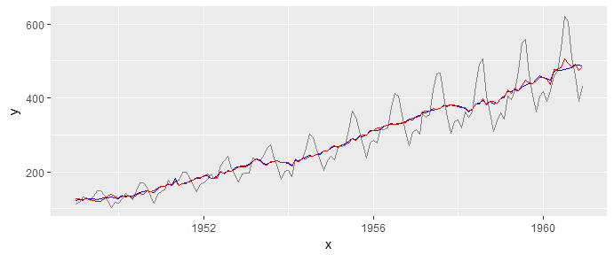

```r
ggplot(ap_df, aes(x = x, y = y)) +
   geom_line(colour = "grey50") +
   stat_seas(colour = "blue") +
   stat_stl(s.window = 7, colour = "red")
```

Check out the helpfiles for more options. For example, you can convert the data to an index first, or pass more advanced arguments to the underlying time series programs.

### Leverage `ggplot2` and seasonal adjustment

One of the more interesting implications of bringing seasonal adjustment into the `ggplot2` universe is the ability to slice and dice the data by aesthetic mappings (usually to colour) by faceting. This all works seamlessly in a way that will be familiar to `ggplot2` users eg

```
Calculating starting date of 1974 from the data.
```

```
Calculating frequency of 12 from the data.
```

```
Calculating starting date of 1974 from the data.
```

```
Calculating frequency of 12 from the data.
```

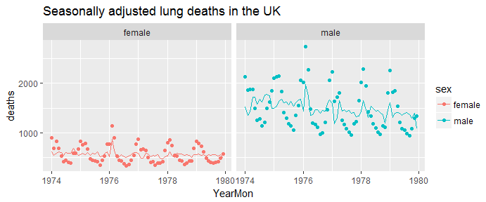

```r
ggplot(ldeaths_df, aes(x = YearMon, y = deaths, colour = sex)) +
  geom_point() +
  facet_wrap(~sex) +
  stat_seas() +
  ggtitle("Seasonally adjusted lung deaths in the UK")
```

## `ggsdc` for quick decomposition into trend, seasonal and random components

The final key functionality from the `ggseas` package is the ability to do decomposition into trend, seasonal and random components, within the `ggplot` paradigm for polishing, aesthetic mappings, etc. Unlike the `stat_seas()` and its cousins which are stats that fit into the usual `ggplot() + ... +...` pipeline, `ggsdc()` is a replacement for the `ggplot()` function that normally starts that pipeline. `ggsdc()` has to seize control of the faceting operations in the pipeline and a few other things so it can’t be added just as a geom (at least not to this author’s understanding).

`ggsdc()` provides access to classic decomposition (additive or multiplicative) from `decompose()`, loess-based via `stl()`, or X13-SEATS-ARIMA via `seasonal()`. Again, I recommend one of the latter two as the more powerful and flexible approaches to seasonality, much better at handling slowly changing seasonality over time.

Here’s how it works at its simplest:

```
Calculating starting date of 1949 from the data.
```

```
Calculating frequency of 12 from the data.
```

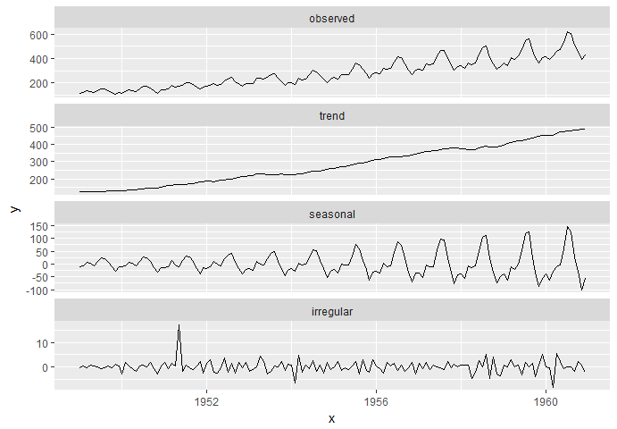

```r
ggsdc(ap_df, aes(x = x, y = y), method = "seas") + geom_line()
```

Note that you still need to add a geom (usually `geom_line()`) to tell ggplot2 how to render the chart

Here’s a slightly more complex version with a multivariate series:

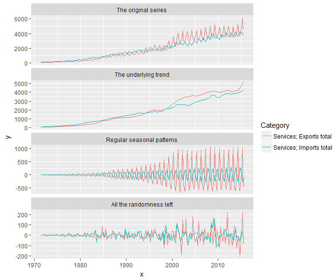

```r
serv <- subset(nzbop, Account == "Current account" &
                  Category %in% c("Services; Exports total", "Services; Imports total"))
ggsdc(serv, aes(x = TimePeriod, y = Value, colour = Category),
         method = "stl", s.window = 7, frequency = 4,
         facet.titles = c("The original series", "The underlying trend",
                          "Regular seasonal patterns", "All the randomness left")) +
      geom_line()
```